# Pronostico Demanda

Pilar Prado

24/3/2021

## UNIVERSIDAD CATOLICA BOLIVIANA “SAN PABLO”

[figure not shown]

# GRUPO DE TRABAJO:

# .

## PROBLEMA: SE REQUIERE HACER UN PRONOSTICO DE DEMANDA DE UNA EMPRESA DE DELIVERY

### El cliente es una empresa de entrega de comidas que opera en varias ciudades. Tienen varios centros logísticos en estas ciudades para enviar pedidos de comida a sus clientes. El cliente quiere un pronóstico de la demanda para las próximas semanas para que estos centros planifiquen el stock de materias primas.

### La reposición de la mayoría de las materias primas se realiza semanalmente y, dado que la materia prima es perecedera, la planificación de las adquisiciones es de suma importancia.

## DATA SET

```r
library(readr)
library(ggplot2)

train <- read_csv("D:/TRABAJOR/train.csv")
test <- read_csv("D:/TRABAJOR/test.csv")
```

```r
nrow(train)
```

```
## [1] 456548
```

```r
ncol(train)
```

```
## [1] 9
```

```r
names(train)
```

```
## [1] "id"                    "week"                  "center_id"
## [4] "meal_id"               "checkout_price"        "base_price"
## [7] "emailer_for_promotion" "homepage_featured"     "num_orders"
```

```r
head(train, 20)
```

```
## # A tibble: 20 x 9
##         id  week center_id meal_id checkout_price base_price emailer_for_promot~
##      <dbl> <dbl>     <dbl>   <dbl>          <dbl>      <dbl>               <dbl>
##  1 1379560     1        55    1885           137.       152.                   0
##  2 1466964     1        55    1993           137.       136.                   0
##  3 1346989     1        55    2539           135.       136.                   0
##  4 1338232     1        55    2139           340.       438.                   0
##  5 1448490     1        55    2631           244.       242.                   0
##  6 1270037     1        55    1248           251.       252.                   0
##  7 1191377     1        55    1778           183.       184.                   0
##  8 1499955     1        55    1062           182.       183.                   0
##  9 1025244     1        55    2707           193.       192.                   0
## 10 1054194     1        55    1207           326.       384.                   0
## 11 1469367     1        55    1230           323.       390                    0
## 12 1029333     1        55    2322           322.       388                    0
## 13 1446016     1        55    2290           311.       310.                   0
## 14 1244647     1        55    1727           445.       446.                   0
## 15 1378227     1        55    1109           265.       298.                   1
## 16 1181556     1        55    2640           282.       281.                   0
## 17 1313873     1        55    2306           244.       341.                   0
## 18 1067069     1        55    2126           486        485                    0
## 19 1058482     1        55    2826           307.       306.                   0
## 20 1240935     1        55    1754           289.       289.                   0
## # ... with 2 more variables: homepage_featured <dbl>, num_orders <dbl>
```

```r
tail(train, 20)
```

```
## # A tibble: 20 x 9
##         id  week center_id meal_id checkout_price base_price emailer_for_promot~
##      <dbl> <dbl>     <dbl>   <dbl>          <dbl>      <dbl>               <dbl>
##  1 1032849   145        61    1216           414.       413.                   0
##  2 1469586   145        61    2126           437.       508.                   0
##  3 1038490   145        61    2826           328.       327.                   0
##  4 1394189   145        61    1754           323.       322.                   0
##  5 1357555   145        61    1971           330.       330.                   0
##  6 1176475   145        61    1902           446.       445.                   0
##  7 1133784   145        61    1247           446.       447.                   0
##  8 1379712   145        61    1558           548.       548.                   0
##  9 1306192   145        61    2581           547.       549.                   0
## 10 1371867   145        61    1962           548.       547.                   0
## 11 1055597   145        61    1445           729.       727.                   0
## 12 1372838   145        61    2760           193.       261.                   0
## 13 1035758   145        61    1525           319.       321.                   0
## 14 1010438   145        61    2704           321.       320.                   0
## 15 1116711   145        61    2492           456.       456.                   0
## 16 1271326   145        61    1543           484.       484.                   0
## 17 1062036   145        61    2304           482.       482.                   0
## 18 1110849   145        61    2664           238.       321.                   0
## 19 1147725   145        61    2569           244.       313.                   0
## 20 1361984   145        61    2490           292.       290.                   0
## # ... with 2 more variables: homepage_featured <dbl>, num_orders <dbl>
```

```r
summary(train)
```

```
##        id               week          center_id         meal_id
##  Min.   :1000000   Min.   :  1.00   Min.   : 10.00   Min.   :1062
##  1st Qu.:1124999   1st Qu.: 39.00   1st Qu.: 43.00   1st Qu.:1558
##  Median :1250184   Median : 76.00   Median : 76.00   Median :1993
##  Mean   :1250096   Mean   : 74.77   Mean   : 82.11   Mean   :2024
##  3rd Qu.:1375140   3rd Qu.:111.00   3rd Qu.:110.00   3rd Qu.:2539
##  Max.   :1499999   Max.   :145.00   Max.   :186.00   Max.   :2956
##  checkout_price     base_price     emailer_for_promotion homepage_featured
##  Min.   :  2.97   Min.   : 55.35   Min.   :0.00000       Min.   :0.0000
##  1st Qu.:228.95   1st Qu.:243.50   1st Qu.:0.00000       1st Qu.:0.0000
##  Median :296.82   Median :310.46   Median :0.00000       Median :0.0000
##  Mean   :332.24   Mean   :354.16   Mean   :0.08115       Mean   :0.1092
##  3rd Qu.:445.23   3rd Qu.:458.87   3rd Qu.:0.00000       3rd Qu.:0.0000
##  Max.   :866.27   Max.   :866.27   Max.   :1.00000       Max.   :1.0000
##    num_orders
##  Min.   :   13.0
##  1st Qu.:   54.0
##  Median :  136.0
##  Mean   :  261.9
##  3rd Qu.:  324.0
##  Max.   :24299.0
```

```r
str(train)
```

```
## spec_tbl_df [456,548 x 9] (S3: spec_tbl_df/tbl_df/tbl/data.frame)
##  $ id                   : num [1:456548] 1379560 1466964 1346989 1338232 1448490 ...
##  $ week                 : num [1:456548] 1 1 1 1 1 1 1 1 1 1 ...
##  $ center_id            : num [1:456548] 55 55 55 55 55 55 55 55 55 55 ...
##  $ meal_id              : num [1:456548] 1885 1993 2539 2139 2631 ...
##  $ checkout_price       : num [1:456548] 137 137 135 340 244 ...
##  $ base_price           : num [1:456548] 152 136 136 438 242 ...
##  $ emailer_for_promotion: num [1:456548] 0 0 0 0 0 0 0 0 0 0 ...
##  $ homepage_featured    : num [1:456548] 0 0 0 0 0 0 0 0 0 1 ...
##  $ num_orders           : num [1:456548] 177 270 189 54 40 28 190 391 472 676 ...
##  - attr(*, "spec")=
##   .. cols(
##   ..   id = col_double(),
##   ..   week = col_double(),
##   ..   center_id = col_double(),
##   ..   meal_id = col_double(),
##   ..   checkout_price = col_double(),
##   ..   base_price = col_double(),
##   ..   emailer_for_promotion = col_double(),
##   ..   homepage_featured = col_double(),
##   ..   num_orders = col_double()
##   .. )
```

# .

### Vamos a retirar de la tabla todas las observaciones en las que no hay informacion para la variable meal_id

```r
sum(is.na(train$meal_id))
```

```
## [1] 0
```

# .

### Distribucion de la variable de respuesta

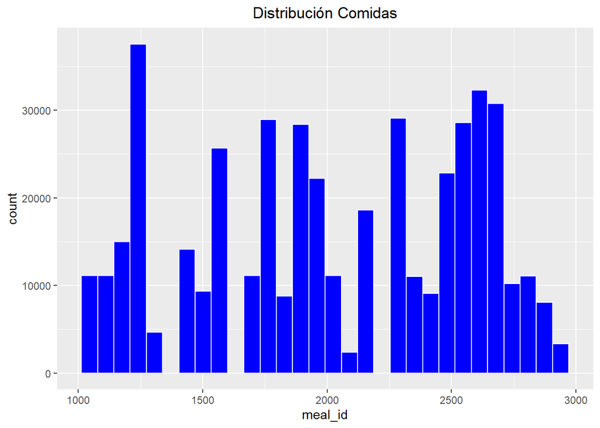

```r
ggplot(data = train, aes(x = meal_id)) +
  geom_histogram(color = "white", fill = "blue") +
  labs(title = "Distribución Comidas") +
  theme(plot.title = element_text(hjust = 0.5))
```

### La distribucion de la variable Meal Id no es una distribución normal por lo que se procederá a normalizarla.

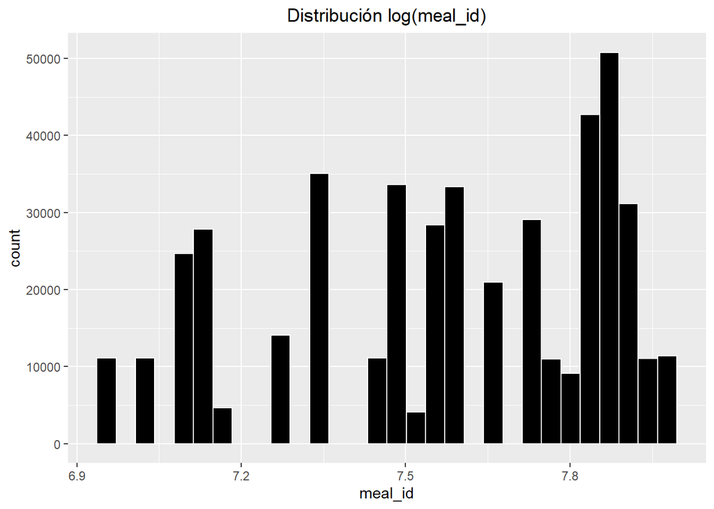

```r
train$meal_id <- log(train$meal_id)

ggplot(data = train, aes(x = meal_id)) + geom_histogram(color = "white", fill = "black") + labs(title = "Distribución log(meal_id)") +  theme(plot.title = element_text(hjust = 0.5))
```

# ARBOL DE REGRESION SIMPLE

```r
library(tree)
# Selección de parámetros para el árbol

setup <- tree.control(nobs = nrow(train), mincut = 10, minsize = 20,mindev = 0.01)

modelo_arbolR <- tree(meal_id ~ ., data = train, split = "deviance", control = setup)

summary(modelo_arbolR)
```

```
##
## Regression tree:
## tree(formula = meal_id ~ ., data = train, control = setup, split = "deviance")
## Variables actually used in tree construction:
## [1] "base_price"
## Number of terminal nodes:  7
## Residual mean deviance:  0.07224 = 32980 / 456500
## Distribution of residuals:
##     Min.  1st Qu.   Median     Mean  3rd Qu.     Max.
## -0.74300 -0.23420  0.02786  0.00000  0.20870  0.55940
```

# .

# PLOTEO DEL ARBOL

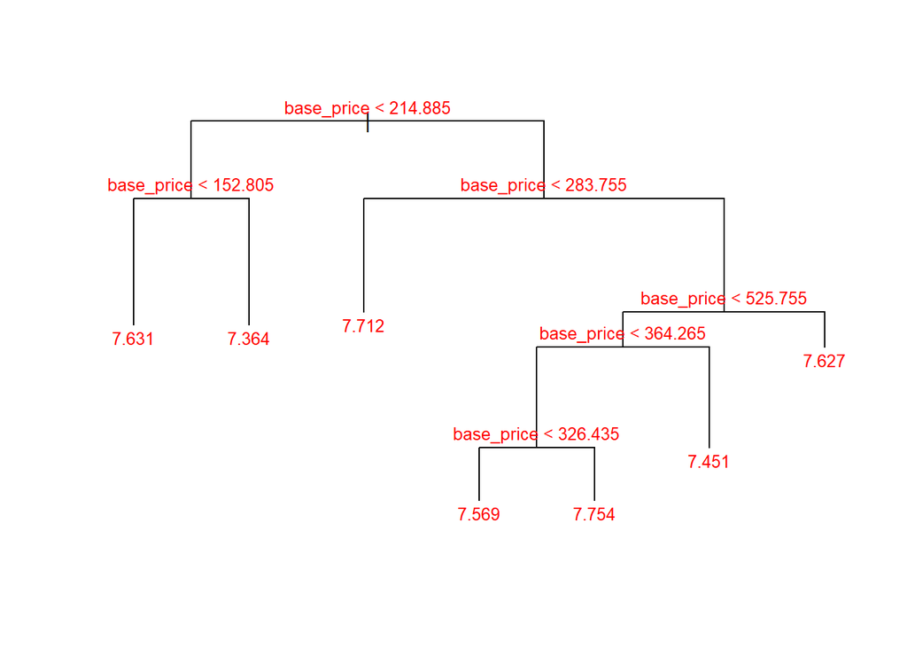

```r
plot(modelo_arbolR, type = "proportional")


text(modelo_arbolR, splits = TRUE, pretty = 0, cex = 0.8, col = "red")
```

```r
modelo_arbolR
```

```
## node), split, n, deviance, yval
##       * denotes terminal node
##
##  1) root 456548 39210 7.572
##    2) base_price < 214.885 88643  8313 7.479
##      4) base_price < 152.805 38455  1565 7.631 *
##      5) base_price > 152.805 50188  5193 7.364 *
##    3) base_price > 214.885 367905 29940 7.595
##      6) base_price < 283.755 79597  4940 7.712 *
##      7) base_price > 283.755 288308 23610 7.562
##       14) base_price < 525.755 211685 18530 7.539
##         28) base_price < 364.265 120812 11110 7.605
##           56) base_price < 326.435 97218  9270 7.569 *
##           57) base_price > 326.435 23594  1191 7.754 *
##         29) base_price > 364.265 90873  6177 7.451 *
##       15) base_price > 525.755 76623  4646 7.627 *
```

# PREDICCIONES DEL MODELO

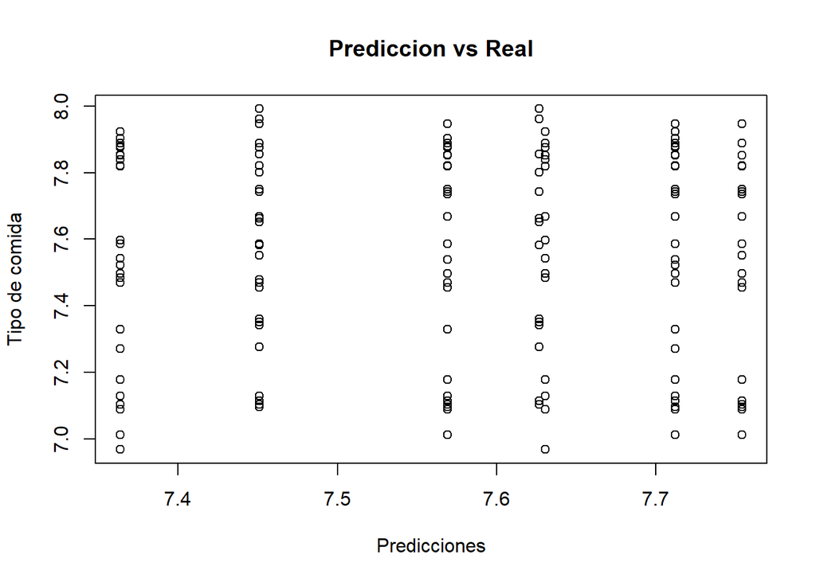

```r
predicciones <- predict(modelo_arbolR, newdata = train)

plot(x= predicciones, y = train$meal_id, main = "Prediccion vs Real", xlab = "Predicciones", ylab = "Tipo de comida")
```